# Data_Cleaning_and_Preprocessing

### Estimator of the Cumulative Distribution Function

#### OBSERVATION

To compare the distribution of Claims before and after the policy change, ECDF plots can be utilized. An ECDF (Empirical Cumulative Distribution Function) represents the cumulative probability distribution of a dataset. For the Claims feature, two ECDFs can be generated - one for Claims before the policy change and another for Claims after the policy change. The x-axis of the ECDF represents the Claims amount, while the y-axis represents the cumulative probability. Similarly, the distribution of Reimbursements before and after the policy change can also be compared using ECDF plots. By computing the ECDF for the Reimbursements feature, the cumulative probability distribution for Reimbursements before the policy change and Reimbursements after the policy change can be visualized. This allows the observation of any differences in the distribution patterns. When interpreting these ECDF plots, it is important to understand the axes. The x-axis represents the variable being analyzed, such as Claims amount or Reimbursements amount. The y-axis represents the cumulative probability, indicating the proportion of values that are less than or equal to a certain value on the x-axis. Additionally, continuous numeric variables like adj_amt and benefit_amount can be considered as alternatives to the Claims and Reimbursements features. By comparing the ECDFs of these variables between the two subsets (before and after the policy change), valuable insights can be gained regarding the differences in these metrics across the two time periods.

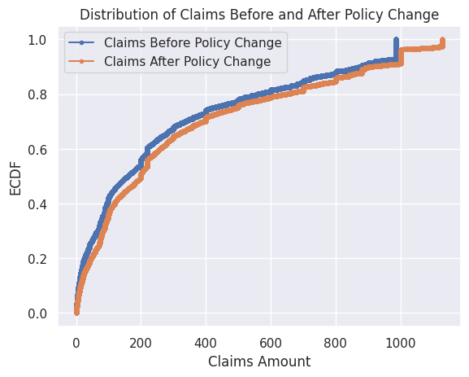

```python
import numpy as np
import matplotlib.pyplot as plt

def ecdf(data):
    """Compute ECDF (Empirical Cumulative Distribution Function)"""
    n = len(data)
    x = np.sort(data)
    y = np.arange(1, n + 1) / n
    return x, y

# ECDF plot for claims before policy change
x_pre, y_pre = ecdf(pre_policy_claims['adj_amt'])
plt.plot(x_pre, y_pre, marker='.', linestyle='-', label='Claims Before Policy Change')

# ECDF plot for claims after policy change
x_post, y_post = ecdf(post_policy_claims['adj_amt'])
plt.plot(x_post, y_post, marker='.', linestyle='-', label='Claims After Policy Change')

plt.xlabel('Claims Amount')
plt.ylabel('ECDF')
plt.legend()
plt.title('Distribution of Claims Before and After Policy Change')
plt.show()
```

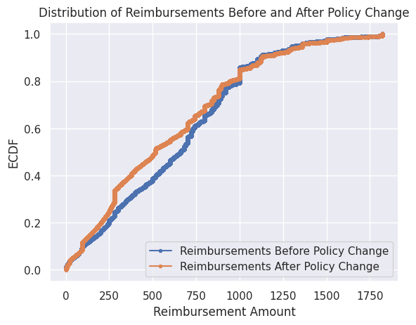

```python
# ECDF plot for reimbursements before policy change
x_pre_reimb, y_pre_reimb = ecdf(reimbursements_pre_policy['benefit_amount'])
plt.plot(x_pre_reimb, y_pre_reimb, marker='.', linestyle='-', label='Reimbursements Before Policy Change')

# ECDF plot for reimbursements after policy change
x_post_reimb, y_post_reimb = ecdf(reimbursements_post_policy['benefit_amount'])
plt.plot(x_post_reimb, y_post_reimb, marker='.', linestyle='-', label='Reimbursements After Policy Change')

plt.xlabel('Reimbursement Amount')
plt.ylabel('ECDF')
plt.legend()
plt.title('Distribution of Reimbursements Before and After Policy Change')
plt.show()
```

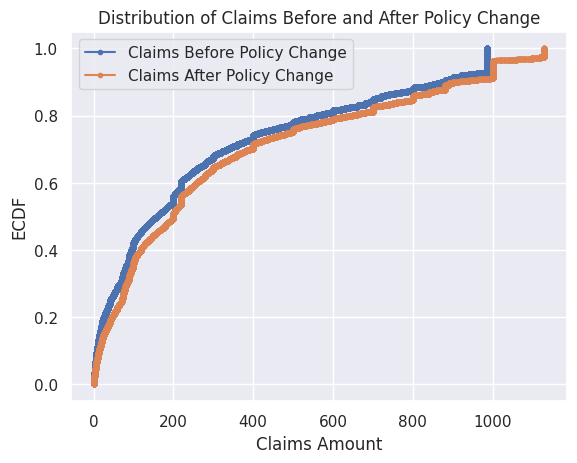

```python
# ECDF plot for adj_amt in pre_policy_claims
x_pre_claims, y_pre_claims = ecdf(pre_policy_claims['adj_amt'])
plt.plot(x_pre_claims, y_pre_claims, marker='.', linestyle='-', label='Claims Before Policy Change')

# ECDF plot for adj_amt in post_policy_claims
x_post_claims, y_post_claims = ecdf(post_policy_claims['adj_amt'])
plt.plot(x_post_claims, y_post_claims, marker='.', linestyle='-', label='Claims After Policy Change')

plt.xlabel('Claims Amount')
plt.ylabel('ECDF')
plt.legend()
plt.title('Distribution of Claims Before and After Policy Change')
plt.show()
```

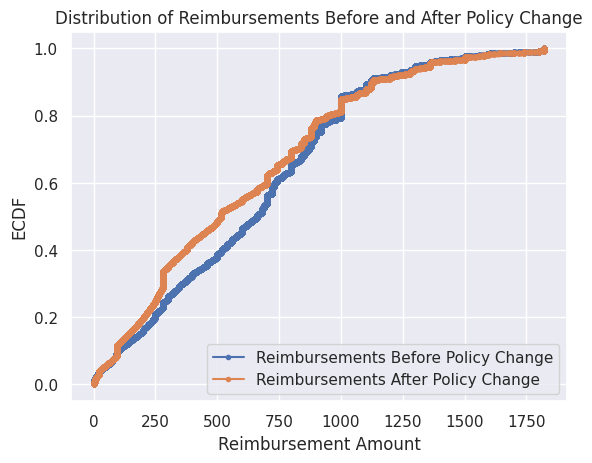

```python
# # ECDF plot for benefit_amount in reimbursements_pre_policy
x_pre_reimb, y_pre_reimb = ecdf(reimbursements_pre_policy['benefit_amount'])
plt.plot(x_pre_reimb, y_pre_reimb, marker='.', linestyle='-', label='Reimbursements Before Policy Change')

# ECDF plot for benefit_amount in reimbursements_post_policy
x_post_reimb, y_post_reimb = ecdf(reimbursements_post_policy['benefit_amount'])
plt.plot(x_post_reimb, y_post_reimb, marker='.', linestyle='-', label='Reimbursements After Policy Change')

plt.xlabel('Reimbursement Amount')
plt.ylabel('ECDF')
plt.legend()
plt.title('Distribution of Reimbursements Before and After Policy Change')
plt.show()
```